# MBON Retrieval and Redeployment Cruise

April 14, 2025 *R/V Daiber* Lewes, DE

### Crew

- **Aaron Carlisle** *UD*
  - Chief Scientist
- **Peter Thielen** *JHU-APL*
  - eDNA Lead
- **Dave Secor** *UMCES*
  - Biotelemetry Lead
- **Caroline Tribble** *UMCES*
  - Acoustics Lead
- **Evan Falgowski** *UD*
  - Captain of *R/V Daiber*
- **Tess Avery** *UD*
  - Field Technician
- **Andrew Paterson & Nick Caloyianis** *MPT*
  - Film Crew joining on Day 1

### Contact Information

- (831) 601-7461 | carlisle@udel.edu
- (240) 470-5979 | Peter.Thielen@jhuapl.edu
- (301) 481-5053 | secor@umces.edu
- (301) 938-0265 | ctribble@umces.edu
- (610) 563-1040 | evanfal@udel.edu
- (617) 599-9681 | tmavery@udel.edu
- (202) 251-7197 | any.trikai@me.com

# Schedule, in brief

### 13 April

- Crew arrives. Loads gear on *R/V Daiber*.

### 14 April

[interactive chart not shown]

# Cruise plan, calculated at 17 knots

- 06:00 Meet at *R/V Daiber*
- 06:30 Depart Lewes for **T-3C**
- **38 20.16, -74 21**
- 09:20 Arrive **T-3C**. Conduct eDNA sampling.
- 09:35 Once eDNA sampling is finished, retrieve current and redeploy new mooring.
- 09:55 Complete operations. Depart for **T-2C**
- **38 20.16, -74 30.3**
- 10:25 Arrive **T-2C**. Conduct eDNA sampling.
- 10:40 Once eDNA sampling is finished, retrieve current and redeploy new mooring.
- 11:00 Complete operations. Depart for **MBON5**
- **38 20.1627, -74 34.66**
- 11:15 Arrive **MBON5**. Conduct eDNA sampling.
- 11:30 Once eDNA sampling is finished, retrieve current and redeploy new mooring.
- 11:50 Complete operations. Depart for **RTWB**
- **38 18.18, -74 38.7**
- 12:05 Arrive **RTWB**.
- 12:20 Filming for MPT at RTWB.
- 12:40 Complete operations. Depart for **MBON4**
- **38 20.1627, -74 39.02**
- 12:50 Arrive **MBON4**. Conduct eDNA sampling.
- 13:05 Once eDNA sampling is finished, retrieve current and redeploy new mooring.
- 13:25 Complete operations. Depart for **A-5C**
- **38 20.16, -74 43.38**
- 13:40 Arrive **A-5C**. Conduct eDNA sampling.
- 13:55 Once eDNA sampling is finished, retrieve current and redeploy new mooring.
- 14:15 Complete operations. Depart for **MBON3**
- **38 20.1629, -74 47.9**
- 14:30 Arrive **MBON3**. Conduct eDNA sampling.
- 14:45 Once eDNA sampling is finished, retrieve current and redeploy new mooring.
- 15:05 Complete operations. Depart for **MBON2**
- **38 20.1629, -74 52.42**
- 15:20 Arrive **MBON2**. Conduct eDNA sampling.
- 15:35 Once eDNA sampling is finished, retrieve current and redeploy new mooring.
- 15:55 Complete operations. Depart for **T-1C**
- **38 20.16, -74 56.94**
- 16:10 Arrive **T-1C**. Conduct eDNA sampling.
- 16:25 Once eDNA sampling is finished, retrieve current and redeploy new mooring.
- 16:45 Complete operations. Depart for **MBON1**
- **38 20.1611, -75 0.9021**
- 17:00 Arrive **MBON1**. Conduct eDNA sampling.
- 17:15 Once eDNA sampling is finished, retrieve current and redeploy new mooring.
- 17:35 Complete operations. Depart for **Lewes**
- 19:20 Arrive **Lewes**.

# Distances

Distance, nautical miles

|  | Lewes | T-3C | T-2C | MBON5 | RTWB | MBON4 | A-5C | MBON3 | MBON2 | T-1C | MBON1 |
| --- | --- | --- | --- | --- | --- | --- | --- | --- | --- | --- | --- |
| Lewes | 0.00 | 47.24 | 41.68 | 39.27 | 38.72 | 37.01 | 34.95 | 33.04 | 31.42 | 30.13 | 29.30 |
| T-3C | 47.24 | 0.00 | 7.30 | 10.72 | 14.04 | 14.14 | 17.57 | 21.11 | 24.66 | 28.21 | 31.32 |
| T-2C | 41.68 | 7.30 | 0.00 | 3.42 | 6.89 | 6.84 | 10.27 | 13.81 | 17.36 | 20.91 | 24.02 |
| MBON5 | 39.27 | 10.72 | 3.42 | 0.00 | 3.74 | 3.42 | 6.84 | 10.39 | 13.94 | 17.49 | 20.60 |
| RTWB | 38.72 | 14.04 | 6.89 | 3.74 | 0.00 | 2.00 | 4.17 | 7.49 | 10.95 | 14.46 | 17.54 |
| MBON4 | 37.01 | 14.14 | 6.84 | 3.42 | 2.00 | 0.00 | 3.42 | 6.97 | 10.52 | 14.07 | 17.18 |
| A-5C | 34.95 | 17.57 | 10.27 | 6.84 | 4.17 | 3.42 | 0.00 | 3.55 | 7.10 | 10.64 | 13.75 |
| MBON3 | 33.04 | 21.11 | 13.81 | 10.39 | 7.49 | 6.97 | 3.55 | 0.00 | 3.55 | 7.10 | 10.21 |
| MBON2 | 31.42 | 24.66 | 17.36 | 13.94 | 10.95 | 10.52 | 7.10 | 3.55 | 0.00 | 3.55 | 6.66 |
| T-1C | 30.13 | 28.21 | 20.91 | 17.49 | 14.46 | 14.07 | 10.64 | 7.10 | 3.55 | 0.00 | 3.11 |
| MBON1 | 29.30 | 31.32 | 24.02 | 20.60 | 17.54 | 17.18 | 13.75 | 10.21 | 6.66 | 3.11 | 0.00 |

Distance, time at 17 kts

|  | Lewes | T-3C | T-2C | MBON5 | RTWB | MBON4 | A-5C | MBON3 | MBON2 | T-1C | MBON1 |
| --- | --- | --- | --- | --- | --- | --- | --- | --- | --- | --- | --- |
| Lewes | - | 02 h 50 m | 02 h 30 m | 02 h 20 m | 02 h 20 m | 02 h 15 m | 02 h 05 m | 02 h 00 m | 01 h 55 m | 01 h 50 m | 01 h 45 m |
| T-3C | 02 h 50 m | - | 00 h 30 m | 00 h 40 m | 00 h 50 m | 00 h 50 m | 01 h 05 m | 01 h 15 m | 01 h 30 m | 01 h 40 m | 01 h 55 m |
| T-2C | 02 h 30 m | 00 h 30 m | - | 00 h 15 m | 00 h 25 m | 00 h 25 m | 00 h 40 m | 00 h 50 m | 01 h 05 m | 01 h 15 m | 01 h 25 m |
| MBON5 | 02 h 20 m | 00 h 40 m | 00 h 15 m | - | 00 h 15 m | 00 h 15 m | 00 h 25 m | 00 h 40 m | 00 h 50 m | 01 h 05 m | 01 h 15 m |
| RTWB | 02 h 20 m | 00 h 50 m | 00 h 25 m | 00 h 15 m | - | 00 h 10 m | 00 h 15 m | 00 h 30 m | 00 h 40 m | 00 h 55 m | 01 h 05 m |
| MBON4 | 02 h 15 m | 00 h 50 m | 00 h 25 m | 00 h 15 m | 00 h 10 m | - | 00 h 15 m | 00 h 25 m | 00 h 40 m | 00 h 50 m | 01 h 05 m |
| A-5C | 02 h 05 m | 01 h 05 m | 00 h 40 m | 00 h 25 m | 00 h 15 m | 00 h 15 m | - | 00 h 15 m | 00 h 30 m | 00 h 40 m | 00 h 50 m |
| MBON3 | 02 h 00 m | 01 h 15 m | 00 h 50 m | 00 h 40 m | 00 h 30 m | 00 h 25 m | 00 h 15 m | - | 00 h 15 m | 00 h 30 m | 00 h 40 m |
| MBON2 | 01 h 55 m | 01 h 30 m | 01 h 05 m | 00 h 50 m | 00 h 40 m | 00 h 40 m | 00 h 30 m | 00 h 15 m | - | 00 h 15 m | 00 h 25 m |
| T-1C | 01 h 50 m | 01 h 40 m | 01 h 15 m | 01 h 05 m | 00 h 55 m | 00 h 50 m | 00 h 40 m | 00 h 30 m | 00 h 15 m | - | 00 h 15 m |
| MBON1 | 01 h 45 m | 01 h 55 m | 01 h 25 m | 01 h 15 m | 01 h 05 m | 01 h 05 m | 00 h 50 m | 00 h 40 m | 00 h 25 m | 00 h 15 m | - |

# Coordinates from Nov ’24 Deployment

[output not shown]

# Retrieval Table

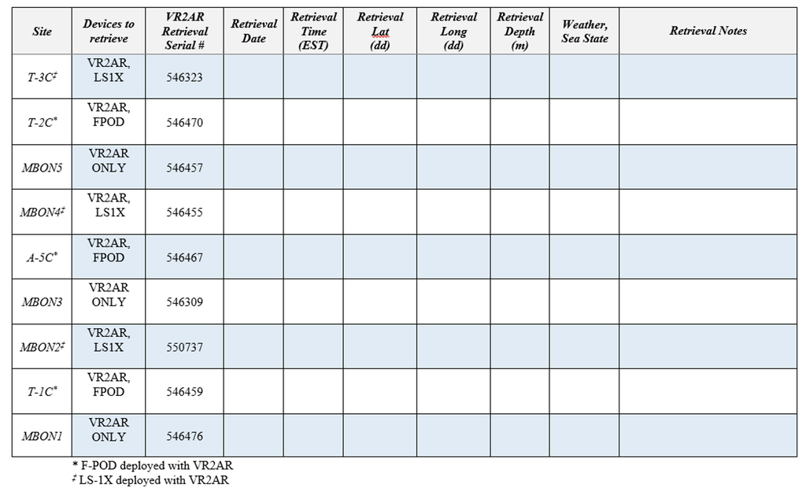

# Deployment Table

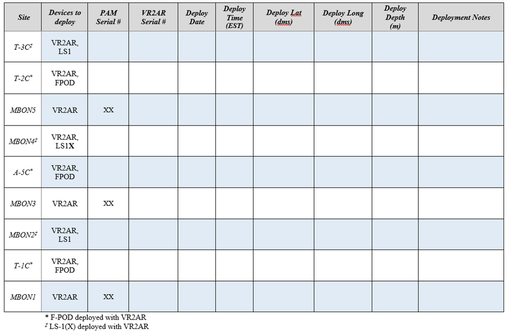

# Mooring Configurations

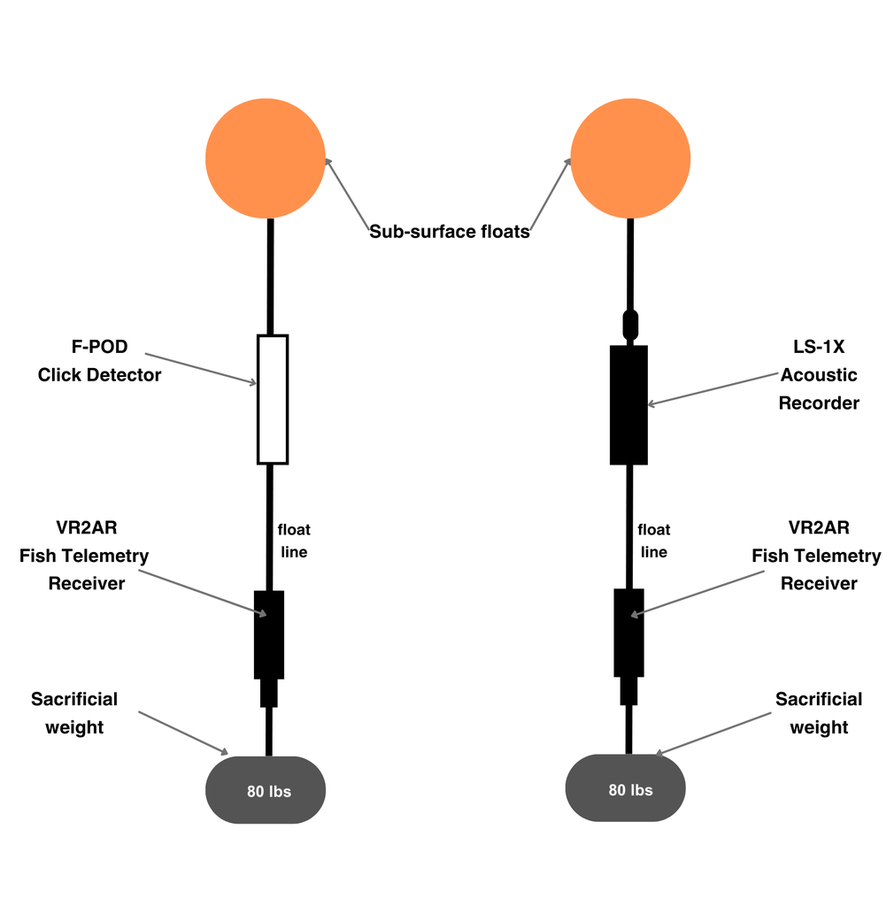

# PAM Device Set-up

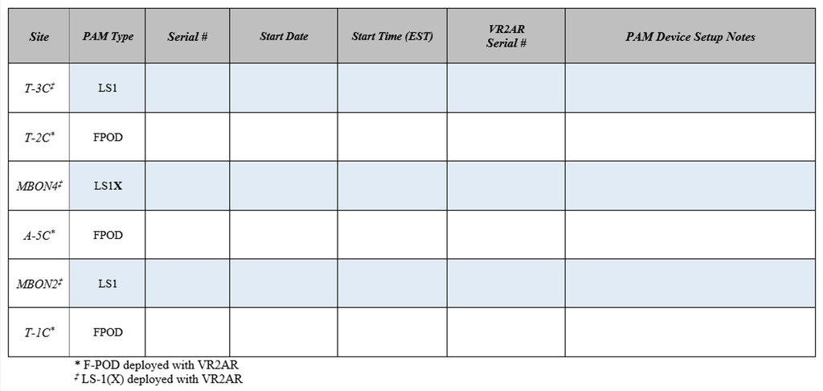

# Supply List

🔲 9 VR2ARs

🔲 3 F-PODS

🔲 1 LS-1X, 2 LS1s (48 kHz sampling rate; duty cycle 5 minutes on and 10 minutes off)

🔲 9 large subsurface buoys

🔲 9-11 sacrificial weights (ranging 80-100 lb)

🔲 Zip Ties - large, medium, and small sizes

🔲 Total of 78 D cell alkaline batteries for F-PODs (30 - 10 each) and LS1s (48 - 24 for LS1X, 12 each for LS1s)

🔲 F-POD, LS-1X microsd memory cards

🔲 F-POD battery springs

🔲 Desiccant packets for PAM devices

🔲 F-POD opening rods

🔲 Garmin handheld GPS

🔲 Datasheets

🔲 Foul weather gear

🔲 Boat shoes

🔲 Life jackets

🔲 Sharpies

🔲 Toolbox

🔲 Work gloves

🔲 VR100 Deckbox

🔲 VR100 Hydrophone